## Personal Fitness Monitoring using activity monitoring devices.

During the past few years, small and light body activity monitoring devices have become popular due to the affordable prices as well as wide spread availability of such devices.

A good amount of data collected by such devices has been collated by enthusiasts and volunteers and this data is now available on the internet.

Enthusiasts like to collect data to maintain their heatlh and/or improve their fitness levels.

This small study demonstrates as to how the data collected by a personal activity monitoring device can be used to process, interpret, display and provide information about the quantum of activity performed.

The raw data provided includes the number of steps taken by an anonymous individual, in 5 minute intervals and collected during the months of October and November 2012.

The data is loaded into R using the following code

```r
#check to see if unzip datafile exists and load it
if (file.exists('activity.csv')){
  a1<-read.csv('activity.csv')
} else {
  unzip('./activity.zip',exdir='./')
  a1<-read.csv('activity.csv')
}
```

The mean total number of steps taken per day can be found by running the following code:

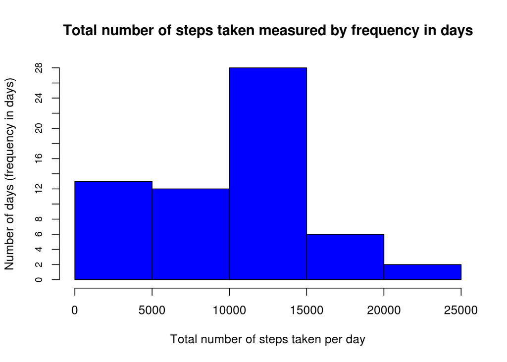

```r
#total number of steps taken per day
#apply the sum function after grouping data by date
a2<-tapply(a1$steps,a1$date,sum,na.rm=T)

#make a data frame from the list
a4<-data.frame(names = row.names(a2), a2)
row.names(a4)<-NULL
names(a4)<-c("dates","steps")

#make/display histogram of total number of steps taken per day
#sequence for tickmarks for y axis
s<-seq(0,28,by=2)

#make the histogram
hist(a4$steps,xlab="Total number of steps taken per day",
              ylab="Number of days (frequency in days)", col="blue",
              main="Total number of steps taken measured by frequency in days",
              yaxt="n")
axis(2,at=s,labels = as.character(s),cex.axis=0.8)
```

```r
#mean and median of total number of steps
a41<-round(mean(a4$steps,na.rm=T))
a42<-round(median(a4$steps,na.rm=T))
print(paste("Mean number of steps per day is", a41))
```

```
## [1] "Mean number of steps per day is 9354"
```

```r
print(paste("Median number of steps per day is", a42))
```

```
## [1] "Median number of steps per day is 10395"
```